# BRIDGES - Analyses d’extraction

Théophile L. Mouton

2026-07-24

> **À propos de ces analyses**

> Ce rapport présente des analyses **préliminaires et exploratoires** réalisées sur un sous-ensemble du corpus BRIDGES : les **207 articles** classés pertinents lors du tri des résumés et dont le texte intégral en accès libre a pu être récupéré automatiquement (sur les 816 articles retenus à ce stade).

> Les données d’extraction (Fiche Articles et Fiche Modèles) ont été produites par **extraction assistée par IA** (modèle Claude Sonnet 4.6, via l’API Anthropic), puis structurées selon nos maquettes d’extraction (v17 et v8). **Ces données n’ont pas encore été validées manuellement.** Elles peuvent contenir des erreurs d’extraction, et les résultats présentés ici doivent être considérés comme un **aperçu méthodologique**, non comme des résultats définitifs.

> L’objectif de ce rapport est double : (1) tester la faisabilité d’une extraction assistée par IA suivie d’une validation humaine, et (2) prototyper les visualisations prévues au calendrier (radars capacités vs utilisation, à venir : heatmap, clusters). La phase de validation des données précédera toute interprétation scientifique.

## Chargement et préparation des données

```r
library(here)
library(readxl)
library(dplyr)
library(tidyr)
library(stringr)
library(readr)
library(ggplot2)

# Fiche Articles : champs en lignes, articles en colonnes -> transposer
chemin <- here("04_extraction", "outputs", "extraction_articles_BRIDGES_REMPLIE.xlsx")
fa <- read_excel(chemin)

cols_articles <- setdiff(names(fa), "Champ")
cols_articles <- cols_articles[!str_detect(cols_articles, "\\[confiance\\]$")]

articles <- fa |>
  select(Champ, all_of(cols_articles)) |>
  pivot_longer(-Champ, names_to = "article", values_to = "valeur") |>
  pivot_wider(names_from = Champ, values_from = valeur)

nrow(articles)  # doit afficher 207
```

```
[1] 207
```

```r
names(articles) # vérifier les colonnes disponibles
```

```
 [1] "article"                 "Type_article"
 [3] "Modele_utilise"          "Milieu"
 [5] "Bassin_oceanique"        "Etendue_spatiale"
 [7] "Resolution_spatiale"     "Resolution_temporelle"
 [9] "Horizon_temporel"        "Util_physique"
[11] "Util_biologique"         "Util_peche"
[13] "Util_economique"         "Util_social"
[15] "Util_spatial"            "Util_temporel"
[17] "Util_scenarios"          "Util_tradeoffs"
[19] "Util_incertitude"        "Type_output"
[21] "Tradeoffs_analyses"      "Tradeoffs_type"
[23] "Contexte_decisionnel"    "Contexte_donnees"
[25] "Compartiments_modelises" "Pertinence_BRIDGES"
[27] "Forces"                  "Limites"
```

## Harmonisation des noms de modèles

```r
# Canonisation : un article -> son modèle principal.
# L'ORDRE compte : familles dominantes / plus spécifiques d'abord.
canoniser_modele <- function(x) {
  l <- str_to_lower(tidyr::replace_na(as.character(x), ""))
  dplyr::case_when(
    l == "" | l == "nan"                                                   ~ "NA (à vérifier)",
    str_detect(l, "ecopath|ecosim|ecospace|ewe|ecotran|rpath|ecotroph")   ~ "Ecopath with Ecosim (EwE)",
    str_detect(l, "atlantis")                                             ~ "Atlantis",
    str_detect(l, "osmose")                                               ~ "OSMOSE",
    str_detect(l, "mizer|size-spectrum|size spectrum")                    ~ "Size-spectrum (mizer)",
    str_detect(l, "displace")                                             ~ "DISPLACE",
    str_detect(l, "corset|hireefsim|simreef")                             ~ "CORSET / dérivés récifaux",
    str_detect(l, "dbem|bioclimate envelope|bioclimatic envelope")        ~ "DBEM (Dynamic Bioclimate Envelope Model)",
    str_detect(l, "mefisto")                                              ~ "MEFISTO",
    str_detect(l, "flbeia")                                               ~ "FLBEIA",
    str_detect(l, "fishrent")                                             ~ "FishRent",
    str_detect(l, "bemtool")                                              ~ "BEMTOOL",
    str_detect(l, "isis-fish|isis fish")                                  ~ "ISIS-Fish",
    str_detect(l, "poseidon")                                             ~ "POSEIDON",
    str_detect(l, "strathe2e")                                            ~ "StrathE2E",
    str_detect(l, "gadget")                                               ~ "Gadget",
    str_detect(l, "sefes")                                                ~ "SEFES",
    str_detect(l, "sprat")                                                ~ "SPRAT",
    str_detect(l, "smart") & str_detect(l, "trawl")                       ~ "SMART",
    str_detect(l, "oceanparcels|lagrangian")                              ~ "Biophysique / Lagrangien",
    str_detect(l, "ergom|getm")                                           ~ "GETM-ERGOM (hydro-biogéochimique)",
    str_detect(l, "loop analysis|qualitative network|signed digraph|qnm|conceptual ecosystem") ~ "Modèle qualitatif (loop analysis / QNM)",
    str_detect(l, "system dynamics|stella|extendsim")                     ~ "System dynamics",
    str_detect(l, "random forest|machine learning")                       ~ "Machine learning (RF, etc.)",
    str_detect(l, "maxent|sdmtmb|species distribution|habitat model|habitat suitability") | l == "sdm" ~ "Species Distribution Model (SDM)",
    str_detect(l, "mice|intermediate complexity|minimally realistic")     ~ "MICE (complexité intermédiaire)",
    str_detect(l, "management strategy evaluation") | str_starts(l, "mse") ~ "MSE (Management Strategy Evaluation)",
    str_detect(l, "earth system model| esm|gcm|cmip|mitgcm|noresm|mpi-esm") ~ "Earth System / Climate model",
    str_detect(l, "bioécon|bioecon|bio-écon|biéconomique|gordon-schaefer|integrated assessment") | str_detect(l, "\\biam\\b") ~ "Modèle bioéconomique",
    str_detect(l, "food web|trophic|ecological network")                  ~ "Modèle trophique / réseau",
    str_detect(l, "population") & str_detect(l, "age|size|matrix|delay-difference|récolte|harvest") ~ "Dynamique de population (structurée)",
    str_detect(l, "surplus production|aspic|cmsy")                        ~ "Production excédentaire",
    str_detect(l, "bayesian")                                             ~ "Modèle bayésien",
    TRUE                                                                  ~ "AUTRE / à classer"
  )
}

articles <- articles |>
  mutate(Modele_canonique = canoniser_modele(Modele_utilise))

# Vérification : effectifs par modèle canonique
articles |>
  count(Modele_canonique, sort = TRUE)
```

```
# A tibble: 29 × 2
   Modele_canonique                             n
   <chr>                                    <int>
 1 Ecopath with Ecosim (EwE)                   69
 2 Modèle bioéconomique                        37
 3 Atlantis                                    17
 4 Species Distribution Model (SDM)            11
 5 OSMOSE                                       9
 6 Earth System / Climate model                 6
 7 DBEM (Dynamic Bioclimate Envelope Model)     5
 8 CORSET / dérivés récifaux                    4
 9 Dynamique de population (structurée)         4
10 MICE (complexité intermédiaire)              4
# ℹ 19 more rows
```

## Distribution géographique des études

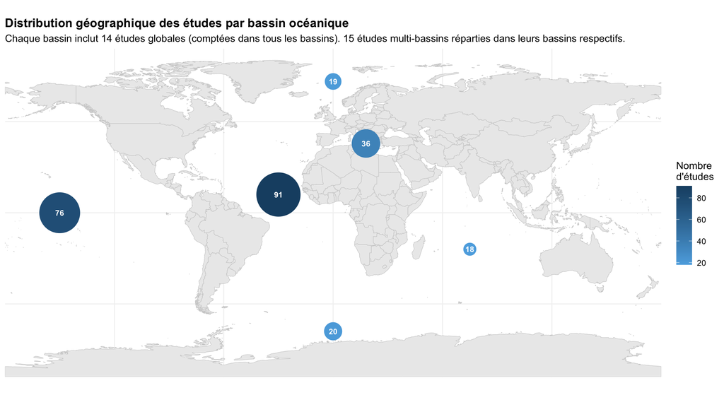

```r
library(sf)
library(rnaturalearth)

# Centroïdes approximatifs de chaque bassin océanique (lon, lat)
centroides <- tibble::tribble(
  ~bassin,          ~lon,   ~lat,
  "Atlantic",       -30,     10,
  "Pacific",       -150,      0,
  "Mediterranean",   18,     38,
  "Southern",         0,    -65,
  "Arctic",           0,     72,
  "Indian",          75,    -20
)

bassins_raw <- articles |>
  filter(!is.na(Bassin_oceanique), Bassin_oceanique != "NA") |>
  select(Bassin_oceanique)

# Nombre d'études globales : ajoutées ensuite à CHAQUE bassin
n_global   <- sum(str_detect(bassins_raw$Bassin_oceanique, "Global"))
n_multiple <- sum(bassins_raw$Bassin_oceanique == "Multiple")

# Comptage des études localisées (hors Global et Multiple), doubles séparés
bassin_localise <- bassins_raw |>
  filter(!str_detect(Bassin_oceanique, "Global"),
         Bassin_oceanique != "Multiple") |>
  separate_rows(Bassin_oceanique, sep = "\\s*;\\s*") |>
  filter(Bassin_oceanique %in% centroides$bassin) |>
  count(Bassin_oceanique, name = "n_local")

# On ajoute les études globales à chaque bassin
bassin_counts <- centroides |>
  left_join(bassin_localise, by = c("bassin" = "Bassin_oceanique")) |>
  mutate(
    n_local = tidyr::replace_na(n_local, 0),
    n = n_local + n_global              # globales ajoutées partout
  )

monde <- ne_countries(scale = "medium", returnclass = "sf")

ggplot() +
  geom_sf(data = monde, fill = "grey92", color = "grey80", linewidth = 0.2) +
  geom_point(data = bassin_counts,
             aes(x = lon, y = lat, size = n, color = n)) +
  geom_text(data = bassin_counts,
            aes(x = lon, y = lat, label = n),
            color = "white", fontface = "bold", size = 3) +
  scale_size_continuous(range = c(6, 22), guide = "none") +
  scale_color_gradient(low = "#5DADE2", high = "#1B4F72", name = "Nombre\nd'études") +
  coord_sf(ylim = c(-90, 90), expand = FALSE) +
  labs(
    title = "Distribution géographique des études par bassin océanique",
    subtitle = paste0("Chaque bassin inclut ", n_global,
                      " études globales (comptées dans tous les bassins). ",
                      n_multiple, " études multi-bassins réparties dans leurs bassins respectifs."),
    x = NULL, y = NULL
  ) +
  theme_minimal(base_size = 11) +
  theme(
    panel.grid = element_line(color = "grey95"),
    axis.text = element_blank(),
    plot.title = element_text(face = "bold")
  )
```

## Évolution temporelle des publications

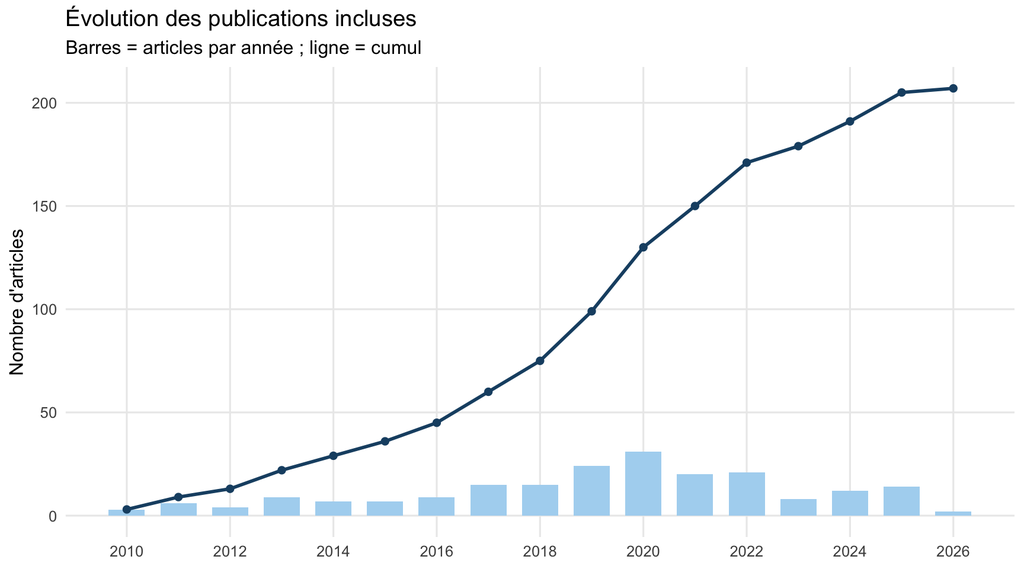

```r
# L'année est encodée au début de l'identifiant article : "2010_EddyTd_478.pdf"
articles <- articles |>
  mutate(annee = as.integer(str_extract(article, "^\\d{4}")))

evolution <- articles |>
  filter(!is.na(annee)) |>
  count(annee, name = "n") |>
  arrange(annee) |>
  mutate(cumul = cumsum(n))

ggplot(evolution, aes(x = annee)) +
  geom_col(aes(y = n), fill = "#AED6F1", width = 0.7) +          # publications par an
  geom_line(aes(y = cumul), color = "#1B4F72", linewidth = 1) +  # cumul
  geom_point(aes(y = cumul), color = "#1B4F72", size = 1.8) +
  scale_x_continuous(breaks = seq(2010, 2026, 2)) +
  labs(
    x = NULL, y = "Nombre d'articles",
    title = "Évolution des publications incluses",
    subtitle = "Barres = articles par année ; ligne = cumul"
  ) +
  theme_minimal(base_size = 12) +
  theme(panel.grid.minor = element_blank())
```

## Saturation de la diversité des frameworks (ordre ASReview)

```r
library(purrr)
library(lubridate)

# --- 1. Charger l'export ASReview (816 inclus, avec asreview_time et auteurs) ---
chemin_asr <- here("03_fulltext", "asreview_relevant_BRIDGES.csv")
asr <- read_csv(chemin_asr, show_col_types = FALSE)

# Ordre ASReview = ordre chronologique des décisions (asreview_time)
asr <- asr |>
  mutate(
    t = ymd_hms(asreview_time),
    key_year   = str_extract(as.character(year), "\\d{4}"),
    key_author = str_to_lower(word(str_split_fixed(authors, ";", 2)[,1], 1))
  ) |>
  arrange(t) |>
  mutate(asr_rank = row_number())

# --- 2. Préparer les 207 : clé année + fragment auteur depuis l'identifiant ---
art_key <- articles |>
  mutate(
    key_year    = str_sub(article, 1, 4),
    author_frag = str_to_lower(str_match(article, "\\d{4}_([A-Za-z\\-]+)_")[,2])
  ) |>
  select(article, Modele_canonique, key_year, author_frag)

# --- 3. Jointure : pour chaque article, le rang ASReview le plus précoce
#        dont l'année correspond et dont le nom d'auteur est préfixe du fragment ---
attribuer_rang <- function(yr, frag, deja_pris) {
  if (is.na(yr) || is.na(frag) || frag == "") return(NA_integer_)
  cand <- asr |>
    filter(
      key_year == yr,
      !is.na(key_author), key_author != "",
      str_starts(frag, key_author) |
        str_starts(key_author, str_sub(frag, 1, pmax(3, nchar(key_author))))
    ) |>
    filter(!asr_rank %in% deja_pris) |>
    arrange(asr_rank)
  if (nrow(cand) == 0) return(NA_integer_)
  cand$asr_rank[1]
}

pris <- integer(0)
art_key$asr_rank <- NA_integer_
for (i in seq_len(nrow(art_key))) {
  rk <- attribuer_rang(art_key$key_year[i], art_key$author_frag[i], pris)
  art_key$asr_rank[i] <- rk
  if (!is.na(rk)) pris <- c(pris, rk)
}

cat("Articles appariés à un rang ASReview :", sum(!is.na(art_key$asr_rank)), "/ 207\n")
```

```
Articles appariés à un rang ASReview : 200 / 207
```

```r
# --- 4. Courbe d'accumulation en ordre ASReview ---
sat_asr <- art_key |>
  filter(!is.na(asr_rank),
         !Modele_canonique %in% c("NA (à vérifier)", "AUTRE / à classer")) |>
  arrange(asr_rank) |>
  mutate(
    rang = row_number(),
    modeles_cumules     = accumulate(Modele_canonique, union),
    n_modeles_distincts = map_int(modeles_cumules, length),
    nouveau             = n_modeles_distincts > lag(n_modeles_distincts, default = 0)
  )

n_total   <- nrow(sat_asr)
n_modeles <- max(sat_asr$n_modeles_distincts)
dernier   <- sat_asr |> filter(nouveau) |> slice_tail(n = 1) |> pull(rang)
cat("Articles analysés        :", n_total, "\n")
```

```
Articles analysés        : 197
```

```r
cat("Frameworks distincts     :", n_modeles, "\n")
```

```
Frameworks distincts     : 27
```

```r
cat("Dernier nouveau framework au rang", dernier,
    "(", n_total - dernier, "articles sans nouveauté ensuite )\n")
```

```
Dernier nouveau framework au rang 171 ( 26 articles sans nouveauté ensuite )
```

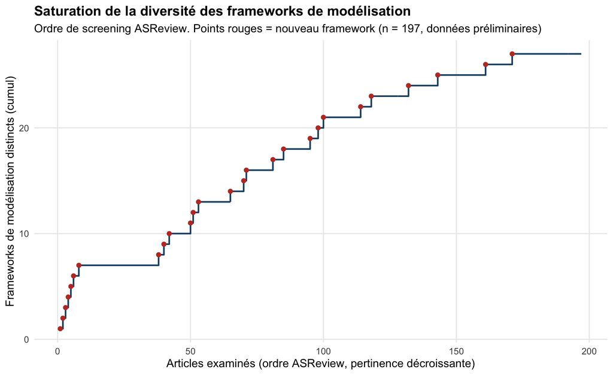

```r
ggplot(sat_asr, aes(rang, n_modeles_distincts)) +
  geom_step(color = "#1B4F72", linewidth = 0.8) +
  geom_point(data = filter(sat_asr, nouveau), color = "#C0392B", size = 1.8) +
  labs(
    x = "Articles examinés (ordre ASReview, pertinence décroissante)",
    y = "Frameworks de modélisation distincts (cumul)",
    title = "Saturation de la diversité des frameworks de modélisation",
    subtitle = paste0("Ordre de screening ASReview. Points rouges = nouveau framework (n = ",
                      n_total, ", données préliminaires)")
  ) +
  theme_minimal(base_size = 12) +
  theme(panel.grid.minor = element_blank(),
        plot.title = element_text(face = "bold"))
```

## Estimateur de richesse (combien de frameworks non encore observés ?)

```r
library(vegan)

# Matrice articles × frameworks (présence/absence) sur les articles appariés
mat_frameworks <- art_key |>
  filter(!is.na(asr_rank),
         !Modele_canonique %in% c("NA (à vérifier)", "AUTRE / à classer")) |>
  mutate(present = 1) |>
  distinct(article, Modele_canonique, present) |>
  pivot_wider(names_from = Modele_canonique, values_from = present, values_fill = 0) |>
  select(-article)

est <- specpool(mat_frameworks)
print(est)
```

```
    Species     chao  chao.se    jack1 jack1.se    jack2     boot  boot.se   n
All      27 31.47716 4.780343 32.96954 2.437056 34.96944 30.04646 1.437231 197
```

```r
obs <- est$Species
chao <- est$chao
cat("\nFrameworks observés        :", obs, "\n")
```

```
Frameworks observés        : 27
```

```r
cat("Frameworks estimés (Chao1) :", round(chao, 1), "\n")
```

```
Frameworks estimés (Chao1) : 31.5
```

```r
cat("Complétude estimée         :", round(100 * obs / chao, 1), "%\n")
```

```
Complétude estimée         : 85.8 %
```

> **Note**

> **À retenir.** L’accumulation des frameworks de modélisation ralentit nettement après la capture rapide des paradigmes dominants (premiers rangs de pertinence ASReview). Sur ce sous-ensemble de 197 articles, 27 frameworks distincts sont identifiés, et l’estimateur Chao1 en estime environ 31,5 au total (erreur standard ≈ 4,8), soit une complétude d’environ 86 %. Autrement dit, la revue aurait déjà capté la grande majorité de la diversité des approches, quelques frameworks supplémentaires restant attendus.

> **Prudence.** La diversité n’est pas encore strictement saturée : de nouveaux frameworks apparaissent encore dans le dernier quart du sous-ensemble. Par ailleurs, ces 197 articles constituent un sous-ensemble contraint par la disponibilité en accès libre, et non l’ensemble du corpus. Cette analyse est donc indicative ; elle peut être reconduite sur un corpus plus large.

## Distribution des modèles

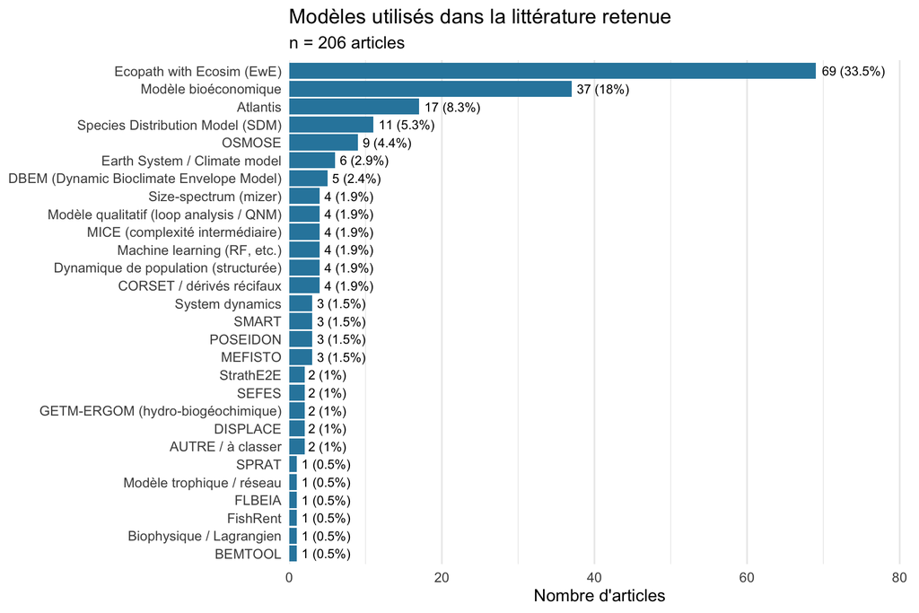

```r
library(ggplot2)
library(forcats)

theme_set(theme_minimal(base_size = 12))

articles |>
  filter(Modele_canonique != "NA (à vérifier)") |>
  count(Modele_canonique) |>
  mutate(
    pct = n / sum(n) * 100,
    Modele_canonique = fct_reorder(Modele_canonique, n)
  ) |>
  ggplot(aes(n, Modele_canonique)) +
  geom_col(fill = "#2E86AB") +
  geom_text(aes(label = paste0(n, " (", round(pct, 1), "%)")),
            hjust = -0.1, size = 3.2) +
  scale_x_continuous(expand = expansion(mult = c(0, 0.18))) +
  labs(
    x = "Nombre d'articles", y = NULL,
    title = "Modèles utilisés dans la littérature retenue",
    subtitle = paste0("n = ", sum(articles$Modele_canonique != "NA (à vérifier)"), " articles")
  ) +
  theme(panel.grid.major.y = element_blank())
```

## Milieux étudiés

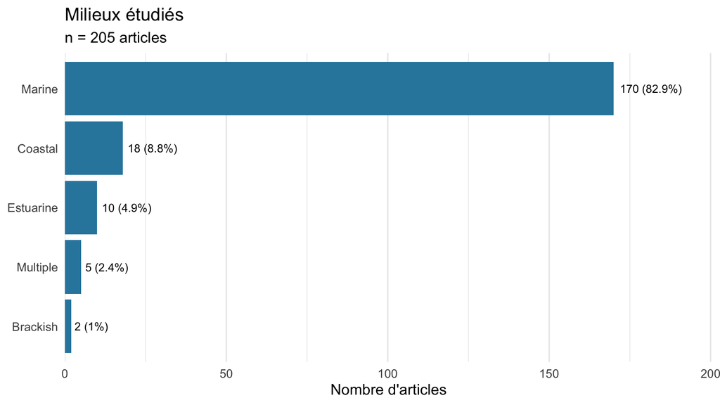

```r
articles |>
  filter(!is.na(Milieu), Milieu != "NA") |>
  count(Milieu) |>
  mutate(
    pct = n / sum(n) * 100,
    Milieu = fct_reorder(Milieu, n)
  ) |>
  ggplot(aes(n, Milieu)) +
  geom_col(fill = "#2E86AB") +
  geom_text(aes(label = paste0(n, " (", round(pct, 1), "%)")),
            hjust = -0.1, size = 3.2) +
  scale_x_continuous(expand = expansion(mult = c(0, 0.18))) +
  labs(
    x = "Nombre d'articles", y = NULL,
    title = "Milieux étudiés",
    subtitle = paste0("n = ", sum(!is.na(articles$Milieu) & articles$Milieu != "NA"), " articles")
  ) +
  theme(panel.grid.major.y = element_blank())
```

## Contextes décisionnels

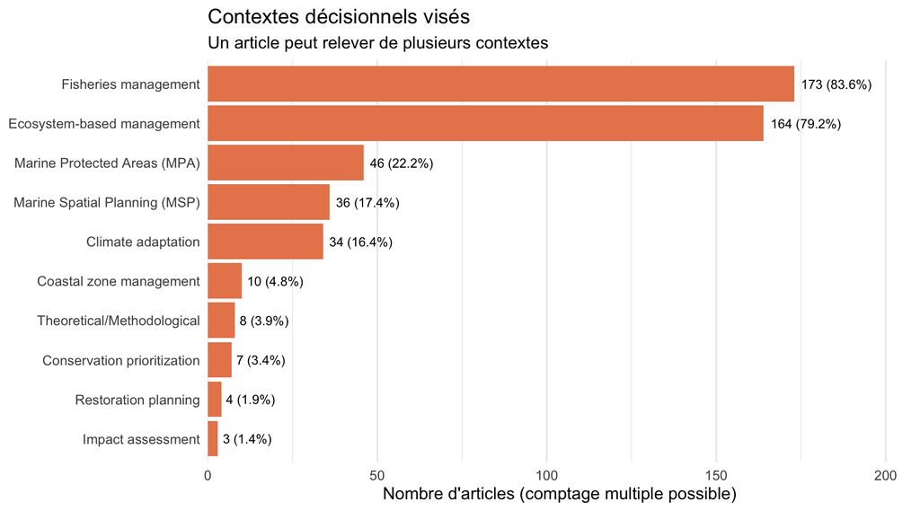

```r
articles |>
  filter(!is.na(Contexte_decisionnel), Contexte_decisionnel != "NA") |>
  separate_rows(Contexte_decisionnel, sep = "\\s*;\\s*") |>
  filter(Contexte_decisionnel != "") |>
  count(Contexte_decisionnel) |>
  mutate(
    pct = n / nrow(articles) * 100,   # % des articles (un article peut compter plusieurs fois)
    Contexte_decisionnel = fct_reorder(Contexte_decisionnel, n)
  ) |>
  ggplot(aes(n, Contexte_decisionnel)) +
  geom_col(fill = "#E8865A") +
  geom_text(aes(label = paste0(n, " (", round(pct, 1), "%)")),
            hjust = -0.1, size = 3.2) +
  scale_x_continuous(expand = expansion(mult = c(0, 0.20))) +
  labs(
    x = "Nombre d'articles (comptage multiple possible)", y = NULL,
    title = "Contextes décisionnels visés",
    subtitle = "Un article peut relever de plusieurs contextes"
  ) +
  theme(panel.grid.major.y = element_blank())
```

## Radar plots : utilisation réelle des capacités par modèle

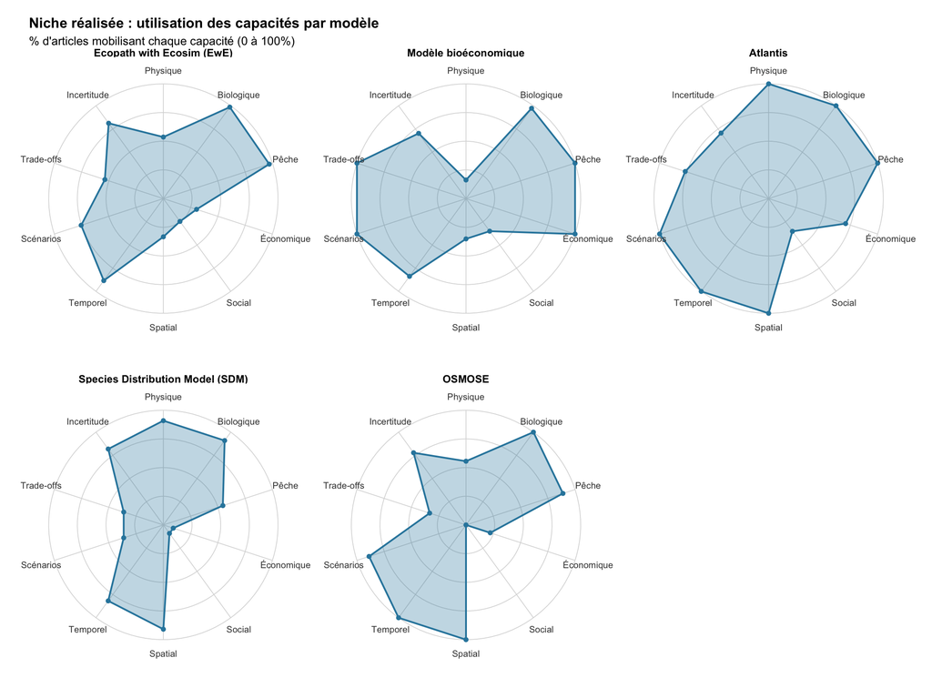

```r
library(tidyr)

util_cols <- c("Util_physique","Util_biologique","Util_peche","Util_economique",
               "Util_social","Util_spatial","Util_temporel","Util_scenarios",
               "Util_tradeoffs","Util_incertitude")
util_labels <- c("Physique","Biologique","Pêche","Économique","Social",
                 "Spatial","Temporel","Scénarios","Trade-offs","Incertitude")

modeles_radar <- c("Ecopath with Ecosim (EwE)", "Modèle bioéconomique",
                   "Atlantis", "Species Distribution Model (SDM)", "OSMOSE")

n_axes <- length(util_cols)

# % d'utilisation par capacité et par modèle, avec angle de chaque axe
radar_data <- articles |>
  filter(Modele_canonique %in% modeles_radar) |>
  select(Modele_canonique, all_of(util_cols)) |>
  pivot_longer(all_of(util_cols), names_to = "capacite", values_to = "valeur") |>
  mutate(oui = as.integer(valeur == "Oui")) |>
  group_by(Modele_canonique, capacite) |>
  summarise(pct = mean(oui, na.rm = TRUE) * 100, .groups = "drop") |>
  mutate(
    axis_id = match(capacite, util_cols),
    angle   = (axis_id - 1) / n_axes * 2 * pi,   # angle de chaque axe (radians)
    x = pct * sin(angle),                        # coordonnées cartésiennes
    y = pct * cos(angle),
    Modele_canonique = factor(Modele_canonique, levels = modeles_radar)
  ) |>
  arrange(Modele_canonique, axis_id)

# Cercles de grille (25/50/75/100) et étiquettes d'axes
grid_levels <- c(25, 50, 75, 100)
circles <- expand.grid(level = grid_levels, t = seq(0, 2*pi, length.out = 100)) |>
  mutate(x = level * sin(t), y = level * cos(t))

axis_pos <- data.frame(
  capacite = util_labels,
  angle = (seq_len(n_axes) - 1) / n_axes * 2 * pi
) |>
  mutate(x = 112 * sin(angle), y = 112 * cos(angle))

spokes <- data.frame(
  angle = (seq_len(n_axes) - 1) / n_axes * 2 * pi
) |>
  mutate(x = 100 * sin(angle), y = 100 * cos(angle), x0 = 0, y0 = 0)

ggplot() +
  # grille circulaire
  geom_path(data = circles, aes(x, y, group = level),
            color = "grey85", linewidth = 0.3) +
  # rayons
  geom_segment(data = spokes, aes(x = x0, y = y0, xend = x, yend = y),
               color = "grey85", linewidth = 0.3) +
  # surface du radar (polygone fermé)
  geom_polygon(data = radar_data, aes(x, y, group = Modele_canonique),
               fill = "#2E86AB", alpha = 0.30, color = "#2E86AB", linewidth = 0.7) +
  geom_point(data = radar_data, aes(x, y), color = "#2E86AB", size = 1.4) +
  # étiquettes des axes
  geom_text(data = axis_pos, aes(x, y, label = capacite), size = 2.7, color = "grey25") +
  facet_wrap(~ Modele_canonique, ncol = 3) +
  coord_equal(clip = "off") +
  labs(
    title = "Niche réalisée : utilisation des capacités par modèle",
    subtitle = "% d'articles mobilisant chaque capacité (0 à 100%)"
  ) +
  theme_void(base_size = 10) +
  theme(
    strip.text = element_text(face = "bold", size = 9),
    plot.title = element_text(face = "bold"),
    panel.spacing = unit(2, "lines"),
    plot.margin = margin(10, 20, 10, 20)
  )
```

> **Note**

> **À retenir.** Les modèles écosystémiques complets (Atlantis, EwE) couvrent un large éventail de capacités, tandis que les SDM se concentrent sur les dimensions biophysique et spatiale. Sur l’ensemble des modèles, la dimension **sociale** reste la moins mobilisée, ce qui suggère que la composante humaine des socio-écosystèmes marins demeure peu intégrée dans les outils de modélisation actuels.

## Consolidation de la Fiche Modèles (consensus des capacités)

```r
# Charger la Fiche Modèles (champs en lignes, modèles en colonnes)
chemin_fm <- here("04_extraction", "outputs", "fiche_modeles_BRIDGES_REMPLIE.xlsx")
fm <- read_excel(chemin_fm)

cols_fm <- setdiff(names(fm), "Champ")
cols_fm <- cols_fm[!str_detect(cols_fm, "\\[confiance\\]$")]

# Transposer : une ligne par fiche-modèle
modeles_raw <- fm |>
  select(Champ, all_of(cols_fm)) |>
  pivot_longer(-Champ, names_to = "fiche", values_to = "valeur") |>
  pivot_wider(names_from = Champ, values_from = valeur) |>
  mutate(Modele_canonique = canoniser_modele(Nom_modele))

# Les 11 champs Cap_
cap_cols <- c("Cap_physique","Cap_biologique","Cap_peche","Cap_economique",
              "Cap_social","Cap_spatial","Cap_temporel","Cap_scenarios",
              "Cap_tradeoffs","Cap_incertitude","Cap_participation")

# Conversion Oui/Optionnel/Non -> 1 / 0.5 / 0
vers_num <- function(x) dplyr::case_when(
  str_to_lower(x) == "oui"       ~ 1,
  str_to_lower(x) == "optionnel" ~ 0.5,
  str_to_lower(x) == "non"       ~ 0,
  TRUE                           ~ NA_real_
)

# Niveaux valides de l'échelle
niveaux_valides <- c(0, 0.5, 1)

# Consensus : mode ; en cas d'égalité, moyenne ramenée au niveau valide le plus proche
consensus_cap <- function(x) {
  x <- x[!is.na(x)]
  if (length(x) == 0) return(NA_real_)
  tb <- table(x)
  modes <- as.numeric(names(tb)[tb == max(tb)])
  if (length(modes) == 1) {
    modes
  } else {
    moy <- mean(modes)                                   # ex: {0, 0.5} -> 0.25
    niveaux_valides[which.min(abs(niveaux_valides - moy))] # -> 0.5
  }
}

# Degré d'accord : part de fiches portant la valeur consensus
accord_cap <- function(x) {
  x <- x[!is.na(x)]
  if (length(x) == 0) return(NA_real_)
  cons <- consensus_cap(x)
  mean(x == cons)
}

modeles_long <- modeles_raw |>
  select(Modele_canonique, all_of(cap_cols)) |>
  pivot_longer(all_of(cap_cols), names_to = "capacite", values_to = "valeur") |>
  mutate(num = vers_num(valeur))

# Consensus par modèle x capacité
fiche_modeles_consensus <- modeles_long |>
  group_by(Modele_canonique, capacite) |>
  summarise(
    n_fiches = sum(!is.na(num)),
    cap_consensus = consensus_cap(num),
    accord = accord_cap(num),
    .groups = "drop"
  )

# Aperçu pour les 5 modèles des radars
modeles_radar <- c("Ecopath with Ecosim (EwE)", "Modèle bioéconomique",
                   "Atlantis", "Species Distribution Model (SDM)", "OSMOSE")

fiche_modeles_consensus |>
  filter(Modele_canonique %in% modeles_radar) |>
  arrange(Modele_canonique, capacite) |>
  print(n = 100)
```

```
# A tibble: 55 × 5
   Modele_canonique                 capacite       n_fiches cap_consensus accord
   <chr>                            <chr>             <int>         <dbl>  <dbl>
 1 Atlantis                         Cap_biologique        1           1    1
 2 Atlantis                         Cap_economique        1           1    1
 3 Atlantis                         Cap_incertitu…        1           0.5  1
 4 Atlantis                         Cap_participa…        1           0    1
 5 Atlantis                         Cap_peche             1           1    1
 6 Atlantis                         Cap_physique          1           1    1
 7 Atlantis                         Cap_scenarios         1           1    1
 8 Atlantis                         Cap_social            1           0.5  1
 9 Atlantis                         Cap_spatial           1           1    1
10 Atlantis                         Cap_temporel          1           1    1
11 Atlantis                         Cap_tradeoffs         1           1    1
12 Ecopath with Ecosim (EwE)        Cap_biologique        2           1    1
```

[output cut: 43 more lines]

## Radar plots : niche réalisée vs niche fondamentale

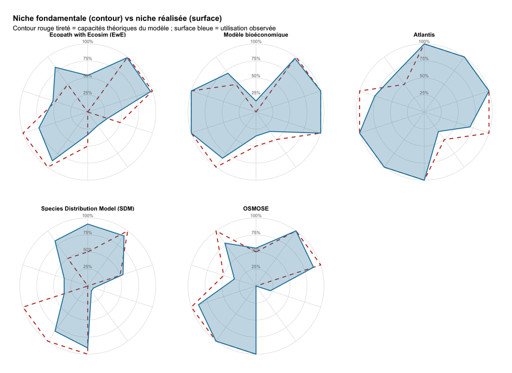

```r
# Axes communs aux deux fiches : 10 axes (sans participation, absent des Util_)
axes_communs <- c("physique","biologique","peche","economique","social",
                  "spatial","temporel","scenarios","tradeoffs","incertitude")
axes_labels  <- c("Physique","Biologique","Pêche","Économique","Social",
                  "Spatial","Temporel","Scénarios","Trade-offs","Incertitude")
n_axes <- length(axes_communs)

# 1) Niche réalisée (déjà calculée) : on repart de radar_data en % -> ramené sur 0..1
realisee <- radar_data |>
  transmute(
    Modele_canonique,
    axe = tolower(gsub("Util_", "", as.character(capacite))),  # sécurité
    valeur = pct / 100,
    type = "Niche réalisée"
  )

# radar_data a déjà des labels ; on reconstruit proprement depuis articles pour être sûr
realisee <- articles |>
  filter(Modele_canonique %in% modeles_radar) |>
  select(Modele_canonique, starts_with("Util_")) |>
  pivot_longer(starts_with("Util_"), names_to = "axe", values_to = "v") |>
  mutate(axe = gsub("Util_", "", axe), oui = as.integer(v == "Oui")) |>
  group_by(Modele_canonique, axe) |>
  summarise(valeur = mean(oui, na.rm = TRUE), .groups = "drop") |>
  mutate(type = "Niche réalisée")

# 2) Niche fondamentale (consensus) sur les mêmes axes
fondamentale <- fiche_modeles_consensus |>
  filter(Modele_canonique %in% modeles_radar) |>
  mutate(axe = gsub("Cap_", "", capacite)) |>
  filter(axe %in% axes_communs) |>
  transmute(Modele_canonique, axe, valeur = cap_consensus, type = "Niche fondamentale")

# 3) Combiner et calculer les coordonnées cartésiennes
radar_combine <- bind_rows(realisee, fondamentale) |>
  mutate(
    axis_id = match(axe, axes_communs),
    angle = (axis_id - 1) / n_axes * 2 * pi,
    x = valeur * 100 * sin(angle),
    y = valeur * 100 * cos(angle),
    Modele_canonique = factor(Modele_canonique, levels = modeles_radar),
    type = factor(type, levels = c("Niche fondamentale", "Niche réalisée"))
  ) |>
  arrange(Modele_canonique, type, axis_id)

# Grille et axes (repris du bloc précédent)
grid_levels <- c(25, 50, 75, 100)
circles <- expand.grid(level = grid_levels, t = seq(0, 2*pi, length.out = 100)) |>
  mutate(x = level * sin(t), y = level * cos(t))

# Étiquettes chiffrées des cercles de grille, placées sur l'axe vertical (haut)
grid_labels <- data.frame(
  level = grid_levels,
  x = 0,
  y = grid_levels
)

spokes <- data.frame(angle = (seq_len(n_axes) - 1) / n_axes * 2 * pi) |>
  mutate(x = 100 * sin(angle), y = 100 * cos(angle), x0 = 0, y0 = 0)
axis_pos <- data.frame(capacite = axes_labels,
                       angle = (seq_len(n_axes) - 1) / n_axes * 2 * pi) |>
  mutate(x = 115 * sin(angle), y = 115 * cos(angle))

ggplot() +
  geom_path(data = circles, aes(x, y, group = level), color = "grey88", linewidth = 0.3) +
  geom_segment(data = spokes, aes(x0, y0, xend = x, yend = y), color = "grey88", linewidth = 0.3) +
  # niche fondamentale = contour seul (pas de remplissage)
  geom_polygon(data = filter(radar_combine, type == "Niche fondamentale"),
               aes(x, y, group = Modele_canonique),
               fill = NA, color = "#C0392B", linewidth = 0.7, linetype = "dashed") +
  # niche réalisée = surface pleine
  geom_polygon(data = filter(radar_combine, type == "Niche réalisée"),
               aes(x, y, group = Modele_canonique),
               fill = "#2E86AB", alpha = 0.30, color = "#2E86AB", linewidth = 0.7) +
  geom_text(data = grid_labels,
          aes(x = x, y = y, label = paste0(level, "%")),
          size = 2.4, color = "grey45",
          hjust = 0.5, vjust = -0.3) +
  facet_wrap(~ Modele_canonique, ncol = 3) +
  coord_equal(clip = "off") +
  labs(
    title = "Niche fondamentale (contour) vs niche réalisée (surface)",
    subtitle = "Contour rouge tireté = capacités théoriques du modèle ; surface bleue = utilisation observée"
  ) +
  theme_void(base_size = 10) +
  theme(
    strip.text = element_text(face = "bold", size = 9),
    plot.title = element_text(face = "bold"),
    panel.spacing = unit(2, "lines"),
    plot.margin = margin(10, 20, 10, 20)
  )
```

## Heatmap comparative des modèles (capacités théoriques)

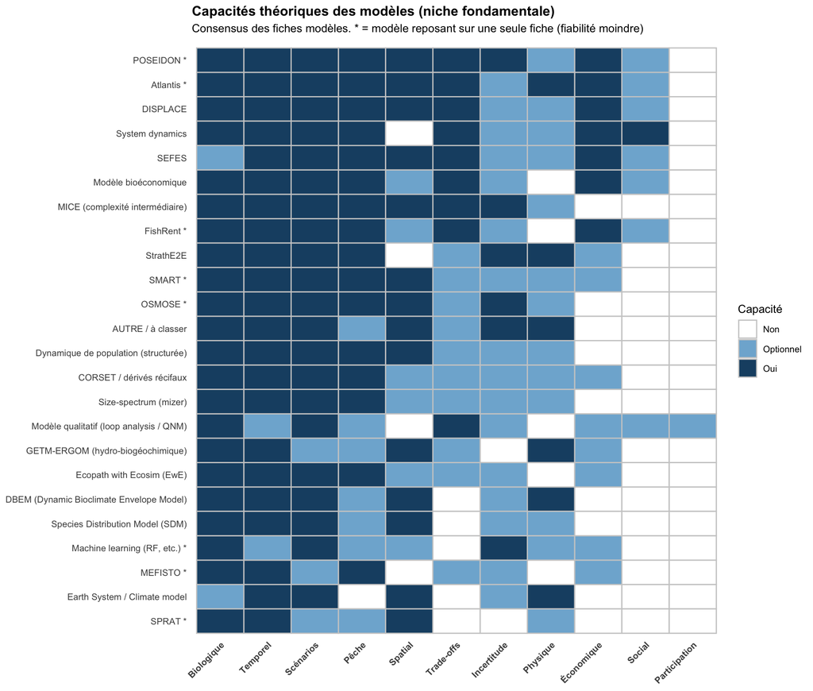

```r
library(forcats)

cap_ordre <- c("Cap_physique","Cap_biologique","Cap_peche","Cap_economique","Cap_social",
               "Cap_spatial","Cap_temporel","Cap_scenarios","Cap_tradeoffs",
               "Cap_incertitude","Cap_participation")
cap_labels <- c("Physique","Biologique","Pêche","Économique","Social",
                "Spatial","Temporel","Scénarios","Trade-offs","Incertitude","Participation")

heatmap_data <- fiche_modeles_consensus |>
  filter(!is.na(cap_consensus), Modele_canonique != "NA (à vérifier)") |>
  mutate(
    capacite = factor(capacite, levels = cap_ordre, labels = cap_labels),
    modele_lab = ifelse(n_fiches == 1, paste0(Modele_canonique, " *"), Modele_canonique),
    niveau = factor(cap_consensus, levels = c(0, 0.5, 1),
                    labels = c("Non", "Optionnel", "Oui"))
  )

# Ordonner les MODÈLES (lignes) par capacité totale croissante
ordre_modeles <- heatmap_data |>
  group_by(modele_lab) |>
  summarise(total = sum(cap_consensus), .groups = "drop") |>
  arrange(total)

# Ordonner les CAPACITÉS (colonnes) par fréquence décroissante : les plus
# couvertes à gauche, les plus rares (Social, Participation) à droite
ordre_capacites <- heatmap_data |>
  group_by(capacite) |>
  summarise(total = sum(cap_consensus), .groups = "drop") |>
  arrange(desc(total))

heatmap_data <- heatmap_data |>
  mutate(
    modele_lab = factor(modele_lab, levels = ordre_modeles$modele_lab),
    capacite   = factor(capacite, levels = ordre_capacites$capacite)
  )

ggplot(heatmap_data, aes(x = capacite, y = modele_lab, fill = niveau)) +
  geom_tile(color = "grey80", linewidth = 0.5) +
  scale_fill_manual(
    values = c("Non" = "white", "Optionnel" = "#7FB3D5", "Oui" = "#1B4F72"),
    name = "Capacité", drop = FALSE
  ) +
  labs(
    x = NULL, y = NULL,
    title = "Capacités théoriques des modèles (niche fondamentale)",
    subtitle = "Consensus des fiches modèles. * = modèle reposant sur une seule fiche (fiabilité moindre)"
  ) +
  theme_minimal(base_size = 10) +
  theme(
    axis.text.x = element_text(angle = 45, hjust = 1, face = "bold"),
    axis.text.y = element_text(size = 8),
    panel.grid = element_blank(),
    plot.title = element_text(face = "bold"),
    plot.subtitle = element_text(margin = margin(b = 10)),
    legend.position = "right"
  )
```

> **Note**

> **Rappel de prudence.** Données préliminaires, fiches non validées. Plusieurs modèles reposent sur une seule fiche (signalés par un astérisque), leur ligne est donc à confirmer.

> **À retenir.** La plupart des modèles couvrent solidement les dimensions biologique, halieutique, spatiale et temporelle. À l’inverse, les dimensions sociale, de participation des acteurs et, dans une moindre mesure, économique sont rarement intégrées. La capacité de participation est quasiment absente, sauf pour les modèles qualitatifs, ce qui souligne le faible ancrage des approches participatives dans les outils de modélisation existants.

## Clusters / familles de modèles (ordination)

> **Note**

> **Note méthodologique.** Cette ordination repose sur les onze capacités théoriques des modèles (`Cap_`), des variables ordinales à trois niveaux (Non, Optionnel, Oui) encodées numériquement (0 / 0,5 / 1). La PCA suppose en principe des variables quantitatives continues : traiter ces capacités ordinales comme numériques est une approximation acceptable pour une visualisation exploratoire, mais impose une équidistance entre niveaux qui reste conventionnelle. Cette ordination est donc indicative. Une version méthodologiquement plus rigoureuse (distance de Gower puis PCoA, ou analyse des correspondances multiples) est envisageable avant publication.

```r
library(ggrepel)

abrev <- c(
  "Ecopath with Ecosim (EwE)" = "EwE",
  "Modèle bioéconomique" = "Bioéconomique",
  "Species Distribution Model (SDM)" = "SDM",
  "DBEM (Dynamic Bioclimate Envelope Model)" = "DBEM",
  "Earth System / Climate model" = "Earth System",
  "Modèle qualitatif (loop analysis / QNM)" = "Qualitatif (QNM)",
  "GETM-ERGOM (hydro-biogéochimique)" = "GETM-ERGOM",
  "Dynamique de population (structurée)" = "Dyn. population",
  "MICE (complexité intermédiaire)" = "MICE",
  "CORSET / dérivés récifaux" = "CORSET",
  "Size-spectrum (mizer)" = "Size-spectrum",
  "Machine learning (RF, etc.)" = "Machine learning",
  "AUTRE / à classer" = "Autre"
)
court <- function(x) ifelse(x %in% names(abrev), abrev[x], x)

mat_cap <- fiche_modeles_consensus |>
  filter(Modele_canonique != "NA (à vérifier)") |>
  select(Modele_canonique, capacite, cap_consensus) |>
  pivot_wider(names_from = capacite, values_from = cap_consensus) |>
  tibble::column_to_rownames("Modele_canonique")
mat_cap <- mat_cap[, sapply(mat_cap, function(x) var(x, na.rm = TRUE) > 0)]
mat_cap[is.na(mat_cap)] <- 0

pca <- prcomp(mat_cap, scale. = TRUE)
var_expl <- round(100 * pca$sdev^2 / sum(pca$sdev^2), 1)

usage <- articles |>
  filter(Modele_canonique != "NA (à vérifier)") |>
  count(Modele_canonique, name = "n_articles")

# Clustering sur les coordonnées AFFICHÉES (PC1, PC2), cohérent avec le visuel
coords_pca <- pca$x[, 1:2]
clust <- hclust(dist(coords_pca), method = "ward.D2")
familles <- cutree(clust, k = 5)   # 5 groupes : 3 nuages + 2 singletons attendus

coords <- as.data.frame(pca$x[, 1:2]) |>
  tibble::rownames_to_column("Modele_canonique") |>
  left_join(usage, by = "Modele_canonique") |>
  mutate(
    n_articles = tidyr::replace_na(n_articles, 1),
    famille = factor(paste("Famille", familles[Modele_canonique])),
    label = court(Modele_canonique)
  )

# --- Repli manuel de l'axe Y pour l'outlier ---
seuil <- -3.0          # en dessous : zone "repliée"
facteur <- 0.25        # compression de la zone repliée
coords <- coords |>
  mutate(
    PC2_plot = ifelse(PC2 < seuil, seuil + (PC2 - seuil) * facteur, PC2)
  ) |>
  arrange(desc(n_articles))   # petits points devant
```

## Variance expliquée par les axes de la PCA

```r
# Part de variance portée par chaque axe principal
var_pct <- round(100 * pca$sdev^2 / sum(pca$sdev^2), 1)
variance_table <- data.frame(
  Axe = paste0("PC", seq_along(var_pct)),
  `Variance (%)` = var_pct,
  `Cumul (%)` = round(cumsum(var_pct), 1),
  check.names = FALSE
)
head(variance_table, 5)   # les 5 premiers axes
```

```
  Axe Variance (%) Cumul (%)
1 PC1         30.8      30.8
2 PC2         19.2      50.0
3 PC3         14.7      64.7
4 PC4         12.8      77.5
5 PC5          6.1      83.6
```

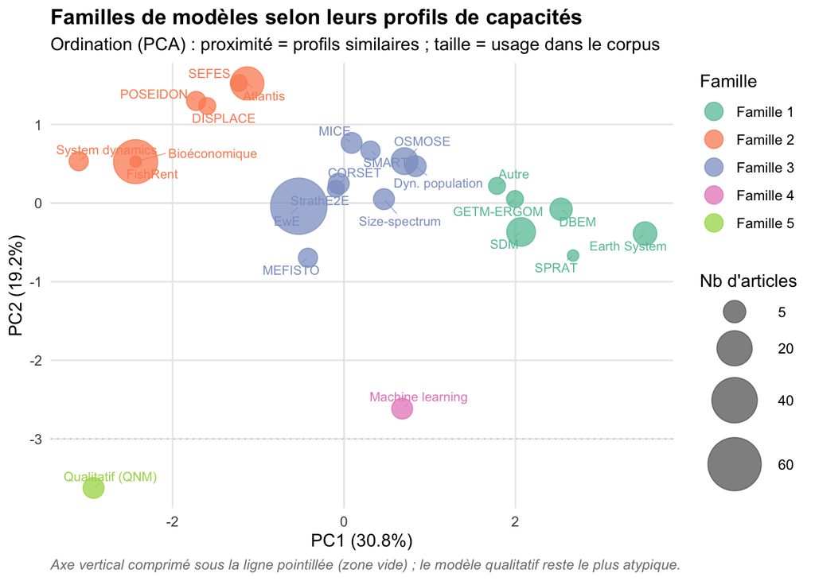

```r
ggplot(coords, aes(PC1, PC2_plot)) +
  geom_hline(yintercept = 0, color = "grey90", linewidth = 0.3) +
  geom_vline(xintercept = 0, color = "grey90", linewidth = 0.3) +
  # marque de rupture d'axe (deux petits traits obliques à gauche)
  annotate("text", x = -Inf, y = seuil, label = "≈", hjust = 1.5, size = 5, color = "grey50") +
  geom_hline(yintercept = seuil, linetype = "dotted", color = "grey75", linewidth = 0.3) +
  geom_point(aes(size = n_articles, color = famille), alpha = 0.75) +
  geom_text_repel(aes(label = label, color = famille),
                  size = 2.8, max.overlaps = 30, show.legend = FALSE,
                  segment.size = 0.2, min.segment.length = 0) +
  scale_size_continuous(range = c(3, 16), name = "Nb d'articles",
                        breaks = c(5, 20, 40, 60)) +
  scale_color_brewer(palette = "Set2", name = "Famille") +
  labs(
    title = "Familles de modèles selon leurs profils de capacités",
    subtitle = "Ordination (PCA) : proximité = profils similaires ; taille = usage dans le corpus",
    x = paste0("PC1 (", var_expl[1], "%)"),
    y = paste0("PC2 (", var_expl[2], "%)"),
    caption = "Axe vertical comprimé sous la ligne pointillée (zone vide) ; le modèle qualitatif reste le plus atypique."
  ) +
  guides(color = guide_legend(override.aes = list(size = 5)),
         size = guide_legend(override.aes = list(color = "grey40"))) +
  theme_minimal(base_size = 11) +
  theme(
    panel.grid.minor = element_blank(),
    plot.title = element_text(face = "bold"),
    plot.caption = element_text(hjust = 0, face = "italic", color = "grey50"),
    legend.position = "right"
  )
```

> **Note**

> **Lecture des familles** (regroupement sur le plan PCA, qui résume environ 50% de la variance des profils de capacités) :
> - **Famille 1 (vert, à droite)** : modèles à dominante biophysique et environnementale, souvent spatialisés (SDM, DBEM, Earth System, GETM-ERGOM, SPRAT).
> - **Famille 2 (orange, à gauche)** : modèles intégrant fortement les dimensions humaines (économique, sociale, flottilles). Modèles bioéconomiques et socio-économiques (modèle bioéconomique, FishRent, System dynamics, SEFES, POSEIDON, DISPLACE, Atlantis).
> - **Famille 3 (violet, centre)** : modèles écosystémiques et de dynamique des populations à dominante biologique et halieutique (EwE, OSMOSE, MICE, SMART, CORSET, Size-spectrum, dynamique de population, MEFISTO).
> - **Famille 4 (Machine learning)** et **Famille 5 (modèle qualitatif / QNM)** : profils atypiques isolés. Le modèle qualitatif se distingue nettement comme le seul à intégrer la participation des acteurs.

> *Familles définies sur les deux axes affichés (50% de la variance) ; données préliminaires, fiches non validées. Les regroupements sont indicatifs. La visualisation place Machine learning loin des SDM, ce qui contredit l’attendu et révèle une fiche à corriger.*